# Project: Investigate a Dataset (No-show appointments)

*Exploring how multiple factors are associated with patients not attending appointments*

## Glossary

- **Poor patients/ Low income patients:** Patients on Bolsa Família Scholarship scheme. Scholarship is a part of a social welfare program
- **Wait-time:** Number of days between scheduling an appointment and attending it
- **Absence rate:** percent of patients who not show up to medical appointment
- Introduction
- Data Wrangling
- Exploratory Data Analysis
- Conclusions

## Introduction

The "No-show appointments" dataset provides information on 100K+ patients in Brazil. The main question to be raised is which factors are associated with patients scheduling doctors appointments while not showing up to them. Around 10 different variables are provided to help answer this question.

In the next sections, I'll start by posing the main questions I brainstormed by just looking at which variables are available to explore. Questions may make use of one or more variables simultaneously. Next, will move into data wrangling to clean the data and make it ready to use. I'll follow this with exploring the research questions through some analysis and visualizations.  
I will end the report with the main conclusions I reached

### Research Questions

1. How does patients' age correlate with showing up to appointment? Does patients' gender affect this relationship?
2. What is the relation between wait time and patients absence rate?
3. Are poor patients more inclined to miss appointments than other patients?
4. How do medical conditions (Hipertension, Diabetes, and/or Alcoholism) affect patients' commitment to attend appointments?

```python
import numpy as np
import pandas as pd
import matplotlib.pyplot as plt
from datetime import date
%matplotlib inline
```

## Data Wrangling

### General Properties

- First, will load and display the data

```python
df = pd.read_csv('no_show_2016.csv')
```

```python
print(df.shape)
df.head(5)
```

```
(110527, 14)
```

|  | PatientId | AppointmentID | Gender | ScheduledDay | AppointmentDay | Age | Neighbourhood | Scholarship | Hipertension | Diabetes | Alcoholism | Handcap | SMS_received | No-show |
| --- | --- | --- | --- | --- | --- | --- | --- | --- | --- | --- | --- | --- | --- | --- |
| 0 | 2.987250e+13 | 5642903 | F | 2016-04-29T18:38:08Z | 2016-04-29T00:00:00Z | 62 | JARDIM DA PENHA | 0 | 1 | 0 | 0 | 0 | 0 | No |
| 1 | 5.589978e+14 | 5642503 | M | 2016-04-29T16:08:27Z | 2016-04-29T00:00:00Z | 56 | JARDIM DA PENHA | 0 | 0 | 0 | 0 | 0 | 0 | No |
| 2 | 4.262962e+12 | 5642549 | F | 2016-04-29T16:19:04Z | 2016-04-29T00:00:00Z | 62 | MATA DA PRAIA | 0 | 0 | 0 | 0 | 0 | 0 | No |
| 3 | 8.679512e+11 | 5642828 | F | 2016-04-29T17:29:31Z | 2016-04-29T00:00:00Z | 8 | PONTAL DE CAMBURI | 0 | 0 | 0 | 0 | 0 | 0 | No |
| 4 | 8.841186e+12 | 5642494 | F | 2016-04-29T16:07:23Z | 2016-04-29T00:00:00Z | 56 | JARDIM DA PENHA | 0 | 1 | 1 | 0 | 0 | 0 | No |

Will use the some comments to get a general sense of the dataset properties

- Describe the data

```python
df.describe()
```

|  | PatientId | AppointmentID | Age | Scholarship | Hipertension | Diabetes | Alcoholism | Handcap | SMS_received |
| --- | --- | --- | --- | --- | --- | --- | --- | --- | --- |
| count | 1.105270e+05 | 1.105270e+05 | 110527.000000 | 110527.000000 | 110527.000000 | 110527.000000 | 110527.000000 | 110527.000000 | 110527.000000 |
| mean | 1.474963e+14 | 5.675305e+06 | 37.088874 | 0.098266 | 0.197246 | 0.071865 | 0.030400 | 0.022248 | 0.321026 |
| std | 2.560949e+14 | 7.129575e+04 | 23.110205 | 0.297675 | 0.397921 | 0.258265 | 0.171686 | 0.161543 | 0.466873 |
| min | 3.921784e+04 | 5.030230e+06 | -1.000000 | 0.000000 | 0.000000 | 0.000000 | 0.000000 | 0.000000 | 0.000000 |
| 25% | 4.172614e+12 | 5.640286e+06 | 18.000000 | 0.000000 | 0.000000 | 0.000000 | 0.000000 | 0.000000 | 0.000000 |
| 50% | 3.173184e+13 | 5.680573e+06 | 37.000000 | 0.000000 | 0.000000 | 0.000000 | 0.000000 | 0.000000 | 0.000000 |
| 75% | 9.439172e+13 | 5.725524e+06 | 55.000000 | 0.000000 | 0.000000 | 0.000000 | 0.000000 | 0.000000 | 1.000000 |
| max | 9.999816e+14 | 5.790484e+06 | 115.000000 | 1.000000 | 1.000000 | 1.000000 | 1.000000 | 4.000000 | 1.000000 |

**Issues**:  
*Age has negative values!*  
*Handicap has a maximum of 4 when it should only have 0/1 values representing (True/False)*

- Checking for Null values or data-type issues

```python
df.info()
```

```
<class 'pandas.core.frame.DataFrame'>
RangeIndex: 110527 entries, 0 to 110526
Data columns (total 14 columns):
 #   Column          Non-Null Count   Dtype
---  ------          --------------   -----
 0   PatientId       110527 non-null  float64
 1   AppointmentID   110527 non-null  int64
 2   Gender          110527 non-null  object
 3   ScheduledDay    110527 non-null  object
 4   AppointmentDay  110527 non-null  object
 5   Age             110527 non-null  int64
 6   Neighbourhood   110527 non-null  object
 7   Scholarship     110527 non-null  int64
 8   Hipertension    110527 non-null  int64
 9   Diabetes        110527 non-null  int64
 10  Alcoholism      110527 non-null  int64
 11  Handcap         110527 non-null  int64
 12  SMS_received    110527 non-null  int64
 13  No-show         110527 non-null  object
dtypes: float64(1), int64(8), object(5)
memory usage: 11.8+ MB
```

*Data looks clean*. However, since many variable types = object, will make sure they're strings

```python
print(type(df['Gender'][0]))
print(type(df['ScheduledDay'][0]))
print(type(df['AppointmentDay'][0]))
print(type(df['No-show'][0]))
print(type(df['Neighbourhood'][0]))
```

```
<class 'str'>
<class 'str'>
<class 'str'>
<class 'str'>
<class 'str'>
```

- Exploring unique values:

```python
df.nunique()
```

```
PatientId          62299
AppointmentID     110527
Gender                 2
ScheduledDay      103549
AppointmentDay        27
Age                  104
Neighbourhood         81
Scholarship            2
Hipertension           2
Diabetes               2
Alcoholism             2
Handcap                5
SMS_received           2
No-show                2
dtype: int64
```

**Issues**:  
*Handicap column has more than 2 values while it shouldn't.*

- *AppointmentID has 110527 unique values which equals the length of the dataset. This may suggest NO duplicate rows*  
  *Will double check this anyway*

```python
df[df.duplicated()].head()
```

|  | PatientId | AppointmentID | Gender | ScheduledDay | AppointmentDay | Age | Neighbourhood | Scholarship | Hipertension | Diabetes | Alcoholism | Handcap | SMS_received | No-show |
| --- | --- | --- | --- | --- | --- | --- | --- | --- | --- | --- | --- | --- | --- | --- |

*No duplicated rows as expected!*

### Potential issues:

1. Mimimum age equals (-1), need to fix this
2. "Handicap" column is both misspelt and contains 5 unique values (0 - 4). It should only contain True/False (or 0/1) according to Kaggle. Since no further information provided, I'll assume that these other values were meant to be 1
3. 'No-show' column has two values (Yes/No). Will convert these values to 0/1 for easier manipulation
4. Based on my questions, many columns are not useful, will drop them

*Finally, will create some new columns I believe will help me with my analysis*

### Data Cleaning (Fixing dataset issues)

#### 1. Fixing Age issue

- Display rows with negative age values

```python
df.query('Age < 0')
```

|  | PatientId | AppointmentID | Gender | ScheduledDay | AppointmentDay | Age | Neighbourhood | Scholarship | Hipertension | Diabetes | Alcoholism | Handcap | SMS_received | No-show |
| --- | --- | --- | --- | --- | --- | --- | --- | --- | --- | --- | --- | --- | --- | --- |
| 99832 | 4.659432e+14 | 5775010 | F | 2016-06-06T08:58:13Z | 2016-06-06T00:00:00Z | -1 | ROMÃO | 0 | 0 | 0 | 0 | 0 | 0 | No |

*Since we can't be sure what the real value is, I'll drop the row and reindex the rows to avoid future issues*

```python
df.drop(99832, axis = 0, inplace =True)
df.reset_index(drop=True, inplace=True)
```

*Now will ensure that the reindexing was successful by checking whether dropped index has new data*

```python
print(df.loc[99832])
df.shape
```

```
PatientId                  2.89827e+13
AppointmentID                  5774075
Gender                               M
ScheduledDay      2016-06-06T07:50:27Z
AppointmentDay    2016-06-06T00:00:00Z
Age                                  1
Neighbourhood           FORTE SÃO JOÃO
Scholarship                          0
Hipertension                         0
Diabetes                             0
Alcoholism                           0
Handcap                              0
SMS_received                         0
No-show                             No
Name: 99832, dtype: object
```

```
(110526, 14)
```

*looks good!*

#### 2- The 'Handicap ' column issues

- Rename the column

```python
df.rename(columns={"Handcap": "Handicap"}, inplace=True)
df.head(2)
```

|  | PatientId | AppointmentID | Gender | ScheduledDay | AppointmentDay | Age | Neighbourhood | Scholarship | Hipertension | Diabetes | Alcoholism | Handicap | SMS_received | No-show |
| --- | --- | --- | --- | --- | --- | --- | --- | --- | --- | --- | --- | --- | --- | --- |
| 0 | 2.987250e+13 | 5642903 | F | 2016-04-29T18:38:08Z | 2016-04-29T00:00:00Z | 62 | JARDIM DA PENHA | 0 | 1 | 0 | 0 | 0 | 0 | No |
| 1 | 5.589978e+14 | 5642503 | M | 2016-04-29T16:08:27Z | 2016-04-29T00:00:00Z | 56 | JARDIM DA PENHA | 0 | 0 | 0 | 0 | 0 | 0 | No |

- Check unique values

```python
df.groupby('Handicap').count()
```

| Handicap | PatientId | AppointmentID | Gender | ScheduledDay | AppointmentDay | Age | Neighbourhood | Scholarship | Hipertension | Diabetes | Alcoholism | SMS_received | No-show |
| --- | --- | --- | --- | --- | --- | --- | --- | --- | --- | --- | --- | --- | --- |
| 0 | 108285 | 108285 | 108285 | 108285 | 108285 | 108285 | 108285 | 108285 | 108285 | 108285 | 108285 | 108285 | 108285 |
| 1 | 2042 | 2042 | 2042 | 2042 | 2042 | 2042 | 2042 | 2042 | 2042 | 2042 | 2042 | 2042 | 2042 |
| 2 | 183 | 183 | 183 | 183 | 183 | 183 | 183 | 183 | 183 | 183 | 183 | 183 | 183 |
| 3 | 13 | 13 | 13 | 13 | 13 | 13 | 13 | 13 | 13 | 13 | 13 | 13 | 13 |
| 4 | 3 | 3 | 3 | 3 | 3 | 3 | 3 | 3 | 3 | 3 | 3 | 3 | 3 |

It's tough to be sure whether numbers >1 means True or False (1 or 0). But I will assume that any number >1 meant to be 1. In any case, adding the entries to either group wouldn't significantly change its relative weight

- Creating a map to convert entries to 0s and 1s

```python
value_map = {0 : 0, 1 : 1, 2: 1, 3: 1, 4: 1}
df['Handicap'] = df['Handicap'].map(value_map)
df.groupby('Handicap').count()
```

| Handicap | PatientId | AppointmentID | Gender | ScheduledDay | AppointmentDay | Age | Neighbourhood | Scholarship | Hipertension | Diabetes | Alcoholism | SMS_received | No-show |
| --- | --- | --- | --- | --- | --- | --- | --- | --- | --- | --- | --- | --- | --- |
| 0 | 108285 | 108285 | 108285 | 108285 | 108285 | 108285 | 108285 | 108285 | 108285 | 108285 | 108285 | 108285 | 108285 |
| 1 | 2241 | 2241 | 2241 | 2241 | 2241 | 2241 | 2241 | 2241 | 2241 | 2241 | 2241 | 2241 | 2241 |

All numbers >1 was mapped to 1 successfully

#### 3. "No-show" column

```
- Replace 'yes' (Patient who did *NOT* show up) with value:1
- Replace 'No' (Patient actually showed up) with value: 0
```

- Will first rename the column for convinience

```python
df.rename(columns={"No-show": "No_show"}, inplace=True)
df.groupby('No_show').count() #Issuing a Pre-count
```

| No_show | PatientId | AppointmentID | Gender | ScheduledDay | AppointmentDay | Age | Neighbourhood | Scholarship | Hipertension | Diabetes | Alcoholism | Handicap | SMS_received |
| --- | --- | --- | --- | --- | --- | --- | --- | --- | --- | --- | --- | --- | --- |
| No | 88207 | 88207 | 88207 | 88207 | 88207 | 88207 | 88207 | 88207 | 88207 | 88207 | 88207 | 88207 | 88207 |
| Yes | 22319 | 22319 | 22319 | 22319 | 22319 | 22319 | 22319 | 22319 | 22319 | 22319 | 22319 | 22319 | 22319 |

```python
df['No_show'] = df['No_show'].map({'No': 0, 'Yes': 1})
```

- Check value count after renaming variables

```python
df.groupby('No_show').count()
```

| No_show | PatientId | AppointmentID | Gender | ScheduledDay | AppointmentDay | Age | Neighbourhood | Scholarship | Hipertension | Diabetes | Alcoholism | Handicap | SMS_received |
| --- | --- | --- | --- | --- | --- | --- | --- | --- | --- | --- | --- | --- | --- |
| 0 | 88207 | 88207 | 88207 | 88207 | 88207 | 88207 | 88207 | 88207 | 88207 | 88207 | 88207 | 88207 | 88207 |
| 1 | 22319 | 22319 | 22319 | 22319 | 22319 | 22319 | 22319 | 22319 | 22319 | 22319 | 22319 | 22319 | 22319 |

Looks good!

#### 4. Will drop columns that I won't use

```python
df.drop(columns=['PatientId', 'AppointmentID', 'Neighbourhood', 'Handicap'], inplace = True)
df.head(2)
```

|  | Gender | ScheduledDay | AppointmentDay | Age | Scholarship | Hipertension | Diabetes | Alcoholism | SMS_received | No_show |
| --- | --- | --- | --- | --- | --- | --- | --- | --- | --- | --- |
| 0 | F | 2016-04-29T18:38:08Z | 2016-04-29T00:00:00Z | 62 | 0 | 1 | 0 | 0 | 0 | 0 |
| 1 | M | 2016-04-29T16:08:27Z | 2016-04-29T00:00:00Z | 56 | 0 | 0 | 0 | 0 | 0 | 0 |

#### Finally, will create two new columns that will help me later with data analysis

- **New column:** Wait_time:  
  *Number of days a patient will wait before appointment. It's calculated by substracting 'ScheduledDay' values from 'AppointmentDay'*

```python
def date_difference (dataframe, column_1, column_2):
    """
    Calculate the number of days between two dates (column_1 - column_2).

    Inputs:
    dataframe: Pandas dataframe that contain date columns
    column_1: first date column
    column_2: second date column

    Outputs:
    number_of_days: a series of values that represents date differences
    """

    number_of_days = pd.Series(range(len(df)))
    counter=0

    for c, d in zip (dataframe[column_1], dataframe[column_2]):

        year_1, year_2 = int(c[0:4]), int(d[0:4])
        month_1, month_2 = int(c[5:7]), int(d[5:7])
        day_1, day_2 = int(c[8:10]), int(d[8:10])

        delta = date(year_1, month_1,day_1) - date(year_2, month_2,day_2)
        result = delta.days

        number_of_days.loc[counter] = result
        counter += 1

    return number_of_days
```

- Append the new column to dataframe

```python
df['Wait_time'] = date_difference(df, 'AppointmentDay', 'ScheduledDay')
```

- Tests to check quickly if calculations are correct

```python
print(df.loc[1234]) #data at a random location
print(df.loc[5673]) #data at a random location
```

```
Gender                               F
ScheduledDay      2016-04-29T14:18:19Z
AppointmentDay    2016-04-29T00:00:00Z
Age                                 19
Scholarship                          0
Hipertension                         0
Diabetes                             0
Alcoholism                           0
SMS_received                         0
No_show                              0
Wait_time                            0
Name: 1234, dtype: object
Gender                               M
ScheduledDay      2016-05-06T06:38:40Z
AppointmentDay    2016-05-10T00:00:00Z
Age                                 34
Scholarship                          0
Hipertension                         0
Diabetes                             0
Alcoholism                           0
SMS_received                         1
No_show                              0
Wait_time                            4
Name: 5673, dtype: object
```

Everything looks good. will do one more check using describe()

```python
df.describe()
```

|  | Age | Scholarship | Hipertension | Diabetes | Alcoholism | SMS_received | No_show | Wait_time |
| --- | --- | --- | --- | --- | --- | --- | --- | --- |
| count | 110526.000000 | 110526.000000 | 110526.000000 | 110526.000000 | 110526.000000 | 110526.000000 | 110526.000000 | 110526.000000 |
| mean | 37.089219 | 0.098266 | 0.197248 | 0.071865 | 0.030400 | 0.321029 | 0.201934 | 10.183794 |
| std | 23.110026 | 0.297676 | 0.397923 | 0.258266 | 0.171686 | 0.466874 | 0.401445 | 15.255034 |
| min | 0.000000 | 0.000000 | 0.000000 | 0.000000 | 0.000000 | 0.000000 | 0.000000 | -6.000000 |
| 25% | 18.000000 | 0.000000 | 0.000000 | 0.000000 | 0.000000 | 0.000000 | 0.000000 | 0.000000 |
| 50% | 37.000000 | 0.000000 | 0.000000 | 0.000000 | 0.000000 | 0.000000 | 0.000000 | 4.000000 |
| 75% | 55.000000 | 0.000000 | 0.000000 | 0.000000 | 0.000000 | 1.000000 | 0.000000 | 15.000000 |
| max | 115.000000 | 1.000000 | 1.000000 | 1.000000 | 1.000000 | 1.000000 | 1.000000 | 179.000000 |

###### New issue:

Minimum Wait_time = -6!. This is illogical since it means the meeting was scheduled after the appointment. Will check this data next

```python
df[df['Wait_time'] <0]
```

|  | Gender | ScheduledDay | AppointmentDay | Age | Scholarship | Hipertension | Diabetes | Alcoholism | SMS_received | No_show | Wait_time |
| --- | --- | --- | --- | --- | --- | --- | --- | --- | --- | --- | --- |
| 27033 | M | 2016-05-10T10:51:53Z | 2016-05-09T00:00:00Z | 38 | 0 | 0 | 0 | 0 | 0 | 1 | -1 |
| 55226 | F | 2016-05-18T14:50:41Z | 2016-05-17T00:00:00Z | 19 | 0 | 0 | 0 | 0 | 0 | 1 | -1 |
| 64175 | F | 2016-05-05T13:43:58Z | 2016-05-04T00:00:00Z | 22 | 0 | 0 | 0 | 0 | 0 | 1 | -1 |
| 71533 | F | 2016-05-11T13:49:20Z | 2016-05-05T00:00:00Z | 81 | 0 | 0 | 0 | 0 | 0 | 1 | -6 |
| 72362 | M | 2016-05-04T06:50:57Z | 2016-05-03T00:00:00Z | 7 | 0 | 0 | 0 | 0 | 0 | 1 | -1 |

*Will Replace these values with mean value (rounding to nearest integer)*

```python
#Rounding to integers is to preserve the column data type
df['Wait_time'].replace(-1,int(df.Wait_time.mean()), inplace=True)
df['Wait_time'].replace(-6,int(df.Wait_time.mean()), inplace=True)

df[df['Wait_time'] <0] #Test if any more negative values still exist
```

|  | Gender | ScheduledDay | AppointmentDay | Age | Scholarship | Hipertension | Diabetes | Alcoholism | SMS_received | No_show | Wait_time |
| --- | --- | --- | --- | --- | --- | --- | --- | --- | --- | --- | --- |

*Looks good!. Now a final test to check if values assigned the mean successfully*

```python
print(df.loc[27033])
print(df.loc[72362])
```

```
Gender                               M
ScheduledDay      2016-05-10T10:51:53Z
AppointmentDay    2016-05-09T00:00:00Z
Age                                 38
Scholarship                          0
Hipertension                         0
Diabetes                             0
Alcoholism                           0
SMS_received                         0
No_show                              1
Wait_time                           10
Name: 27033, dtype: object
Gender                               M
ScheduledDay      2016-05-04T06:50:57Z
AppointmentDay    2016-05-03T00:00:00Z
Age                                  7
Scholarship                          0
Hipertension                         0
Diabetes                             0
Alcoholism                           0
SMS_received                         0
No_show                              1
Wait_time                           10
Name: 72362, dtype: object
```

*Since everything looks good, will drop the date rows (no longer needed).*

```python
df.drop(columns=['ScheduledDay', 'AppointmentDay'], inplace=True)
df.head(10)
```

|  | Gender | Age | Scholarship | Hipertension | Diabetes | Alcoholism | SMS_received | No_show | Wait_time |
| --- | --- | --- | --- | --- | --- | --- | --- | --- | --- |
| 0 | F | 62 | 0 | 1 | 0 | 0 | 0 | 0 | 0 |
| 1 | M | 56 | 0 | 0 | 0 | 0 | 0 | 0 | 0 |
| 2 | F | 62 | 0 | 0 | 0 | 0 | 0 | 0 | 0 |
| 3 | F | 8 | 0 | 0 | 0 | 0 | 0 | 0 | 0 |
| 4 | F | 56 | 0 | 1 | 1 | 0 | 0 | 0 | 0 |
| 5 | F | 76 | 0 | 1 | 0 | 0 | 0 | 0 | 2 |
| 6 | F | 23 | 0 | 0 | 0 | 0 | 0 | 1 | 2 |
| 7 | F | 39 | 0 | 0 | 0 | 0 | 0 | 1 | 2 |
| 8 | F | 21 | 0 | 0 | 0 | 0 | 0 | 0 | 0 |
| 9 | F | 19 | 0 | 0 | 0 | 0 | 0 | 0 | 2 |

##### New Column: Health_score:

- Score represents number of pre-existing medical conditions per patient (0: best, 3: worst). It's calculated by a simple addition of columns ('Hipertension', 'Diabetes', Alcoholism')

```python
df['Health_score'] = (df['Hipertension'] + df['Diabetes'] + df['Alcoholism'])
df.head()
```

|  | Gender | Age | Scholarship | Hipertension | Diabetes | Alcoholism | SMS_received | No_show | Wait_time | Health_score |
| --- | --- | --- | --- | --- | --- | --- | --- | --- | --- | --- |
| 0 | F | 62 | 0 | 1 | 0 | 0 | 0 | 0 | 0 | 1 |
| 1 | M | 56 | 0 | 0 | 0 | 0 | 0 | 0 | 0 | 0 |
| 2 | F | 62 | 0 | 0 | 0 | 0 | 0 | 0 | 0 | 0 |
| 3 | F | 8 | 0 | 0 | 0 | 0 | 0 | 0 | 0 | 0 |
| 4 | F | 56 | 0 | 1 | 1 | 0 | 0 | 0 | 0 | 2 |

```python
df.groupby('Health_score').count() #Ensure that scores assigned successfully
```

| Health_score | Gender | Age | Scholarship | Hipertension | Diabetes | Alcoholism | SMS_received | No_show | Wait_time |
| --- | --- | --- | --- | --- | --- | --- | --- | --- | --- |
| 0 | 85311 | 85311 | 85311 | 85311 | 85311 | 85311 | 85311 | 85311 | 85311 |
| 1 | 17582 | 17582 | 17582 | 17582 | 17582 | 17582 | 17582 | 17582 | 17582 |
| 2 | 7377 | 7377 | 7377 | 7377 | 7377 | 7377 | 7377 | 7377 | 7377 |
| 3 | 256 | 256 | 256 | 256 | 256 | 256 | 256 | 256 | 256 |

*All looks good!*

## Exploratory Data Analysis

### General exploration

- Will start by looking at variable histograms

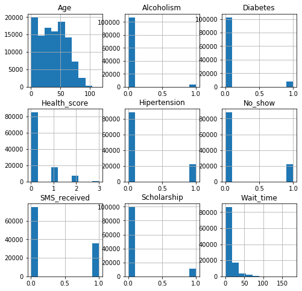

```python
df.hist(figsize=(8,8));
```

**Notes**

- Many histograms are bar-chart like since data is only 0 & 1
- Patients Ages between 0 and 60 years are **almost** evenly distributed
- The majority of Wait_time values are less than 3 weeks
- Around 1/3rd d of patients receive SMS reminders for appointmnets
- Next, will plot a scatter between age and Wait_time  
  *It's worth noting that other scatter relationships won't help much since data is only 0/1*

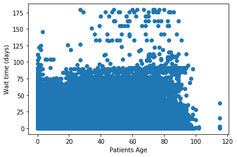

```python
plt.scatter(df.Age, df.Wait_time)
plt.xlabel("Patients Age")
plt.ylabel("Wait time (days)");
```

*This doesn't show much either, apart from some outliers. Will move on to specific questions*

### Research Question 1:

**How does patients' age correlate with showing up to appointment? Does patients' genders affect this relationship?**

**Part-A: Age/attendance relationship**

- First, may use groupby command to see how data is distributed

```python
df.groupby(['No_show'])['Age'].value_counts()
```

```
No_show  Age
0        0      2900
         1      1858
         52     1449
         56     1372
         2      1366
                ...
1        95        6
         115       3
         97        2
         96        1
         98        1
Name: Age, Length: 203, dtype: int64
```

*This doesn't seem to be useful since there is more than 100 unique age values*

```python
df['Age'].max()
```

```
115
```

```python
age_bins = [0,3,12,20,60,116]
age_labels=['Infants', 'Kids','Teens', 'Adults', 'Seniors']
age_groups = pd.cut(df['Age'],age_bins , labels=age_labels, include_lowest=True, right=True)
age_groups[0:10]
```

```
0    Seniors
1     Adults
2    Seniors
3       Kids
4     Adults
5    Seniors
6     Adults
7     Adults
8     Adults
9      Teens
Name: Age, dtype: category
Categories (5, object): [Infants < Kids < Teens < Adults < Seniors]
```

- This looks much better! Will add Age_groups as a new column to the dataset

```python
df['Age_groups'] = age_groups
df.head(3)
```

|  | Gender | Age | Scholarship | Hipertension | Diabetes | Alcoholism | SMS_received | No_show | Wait_time | Health_score | Age_groups |
| --- | --- | --- | --- | --- | --- | --- | --- | --- | --- | --- | --- |
| 0 | F | 62 | 0 | 1 | 0 | 0 | 0 | 0 | 0 | 1 | Seniors |
| 1 | M | 56 | 0 | 0 | 0 | 0 | 0 | 0 | 0 | 0 | Adults |
| 2 | F | 62 | 0 | 0 | 0 | 0 | 0 | 0 | 0 | 0 | Seniors |

```python
df.info()
```

```
<class 'pandas.core.frame.DataFrame'>
RangeIndex: 110526 entries, 0 to 110525
Data columns (total 11 columns):
 #   Column        Non-Null Count   Dtype
---  ------        --------------   -----
 0   Gender        110526 non-null  object
 1   Age           110526 non-null  int64
 2   Scholarship   110526 non-null  int64
 3   Hipertension  110526 non-null  int64
 4   Diabetes      110526 non-null  int64
 5   Alcoholism    110526 non-null  int64
 6   SMS_received  110526 non-null  int64
 7   No_show       110526 non-null  int64
 8   Wait_time     110526 non-null  int64
 9   Health_score  110526 non-null  int64
 10  Age_groups    110526 non-null  category
dtypes: category(1), int64(9), object(1)
memory usage: 8.5+ MB
```

- Next, will create masks for no _show column to separate the data

```python
absent = df.No_show == 1
```

- Then, will calculate age_dist which illustrate absence rate among age groups

```python
age_dist = df.Age_groups[absent].value_counts()/ df.Age_groups.value_counts()
age_dist
```

```
Infants    0.177010
Kids       0.225254
Teens      0.257954
Adults     0.207363
Seniors    0.152110
Name: Age_groups, dtype: float64
```

- Finally, will visualize the results using a bar chart

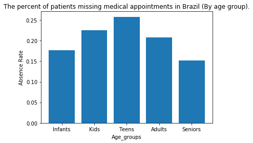

```python
plt.bar(age_labels,age_dist)
plt.xlabel("Age_groups")
plt.ylabel("Absence Rate")
plt.title("The percent of patients missing medical appointments in Brazil (By age group).");
```

#### Insight 1.0:

Absence rate seems to be different for different ages where **Teens** are the age group with the highest rate and **Seniors** looks to be the most committed group. Since results fluctuates with age, it looks like other factors may be affecting both variables

**Part-B: Gender possible influence**

- Again, create gender masks to separate data

```python
males = df.Gender == 'M'
females = df.Gender == 'F'
```

- Then, will calculate male_dist & female_dist find absence rate based on gender

```python
#absence rate - males
male_dist = df.Age_groups[absent][males].value_counts()/ df.Age_groups[males].value_counts()
male_dist
```

```
Infants    0.175157
Kids       0.226371
Teens      0.267262
Adults     0.203007
Seniors    0.143342
Name: Age_groups, dtype: float64
```

```python
#absence rate - feales

female_dist = df.Age_groups[absent][females].value_counts()/ df.Age_groups[females].value_counts()
female_dist
```

```
Adults     0.209202
Seniors    0.156396
Teens      0.253125
Kids       0.223999
Infants    0.178984
Name: Age_groups, dtype: float64
```

**New Issue:**  
*female age groups are not indexed in the same order as males*.

- Will re-index female group data

```python
age_index = ['Infants','Kids', 'Teens', 'Adults','Seniors']
female_dist = female_dist.reindex(index = age_index)
female_dist
```

```
Infants    0.178984
Kids       0.223999
Teens      0.253125
Adults     0.209202
Seniors    0.156396
Name: Age_groups, dtype: float64
```

- Now will visualize the data again but while separating gender data this time

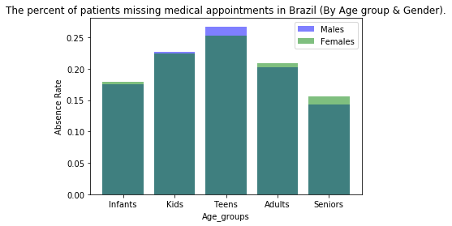

```python
plt.bar(age_labels, male_dist, alpha=0.5, color='blue', label='Males')
plt.bar(age_labels, female_dist, alpha=0.5, color='green', label='Females')
plt.xlabel("Age_groups")
plt.ylabel("Absence Rate")
plt.title("The percent of patients missing medical appointments in Brazil (By Age group & Gender).")
plt.legend();
```

#### Insight 1.1:

Patients' gender doesn't show any significant influence on their absence rate.

### Research Question 2:

**What is the relation between wait time and patients absence rate?**

First, will create a histogram to show two distributions:

- Absent patients: distribution of wait time(in days) for patients not showed up
- All patients: distribution of wait time for everyone

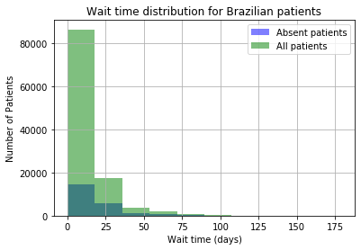

```python
df.Wait_time[absent].hist(color='blue', alpha=0.5, label='Absent patients')
df.Wait_time.hist(color='green', alpha=0.5, label='All patients');
plt.xlabel("Wait time (days)")
plt.ylabel("Number of Patients")
plt.title("Wait time distribution for Brazilian patients")
plt.legend();
```

*Roughly speaking , the histogram above may suggest that a larger percentage of patients may miss the appointment as time increases.* **However,** I would rather discover this further

Again, I would create bins to classify Wait times:

```python
df['Wait_time'].max()
```

```
179
```

```python
time_bins = [0,3,8,30,90, 180]
time_labels=['Instant', 'Short','Intermediate', 'Long', 'Very_long']
time_groups = pd.cut(df['Wait_time'],time_bins , labels=time_labels, include_lowest=True)
```

- Add time groups as a new column

```python
df['Time_groups'] = time_groups
df.tail(3)
```

|  | Gender | Age | Scholarship | Hipertension | Diabetes | Alcoholism | SMS_received | No_show | Wait_time | Health_score | Age_groups | Time_groups |
| --- | --- | --- | --- | --- | --- | --- | --- | --- | --- | --- | --- | --- |
| 110523 | F | 21 | 0 | 0 | 0 | 0 | 1 | 0 | 41 | 0 | Adults | Long |
| 110524 | F | 38 | 0 | 0 | 0 | 0 | 1 | 0 | 41 | 0 | Adults | Long |
| 110525 | F | 54 | 0 | 0 | 0 | 0 | 1 | 0 | 41 | 0 | Adults | Long |

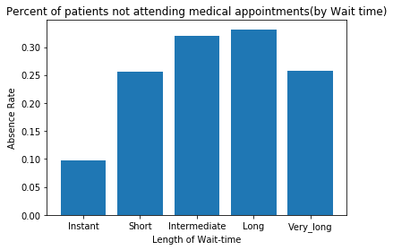

```python
time_dist = df.Time_groups[absent].value_counts()/df.Time_groups.value_counts()
plt.bar(time_labels,time_dist)
plt.xlabel("Length of Wait-time")
plt.ylabel("Absence Rate")
plt.title("Percent of patients not attending medical appointments(by Wait time)");
```

#### Insight 2.0:

**This looks very interesting!** There is a general positive correlation between long wait-time and absence-rate. However, when wait time is very long (>3 months), absence rate starts to drop again.

- To dig deeper into this issue, will start by creating histograms for time-group with Wait_time > 90 days

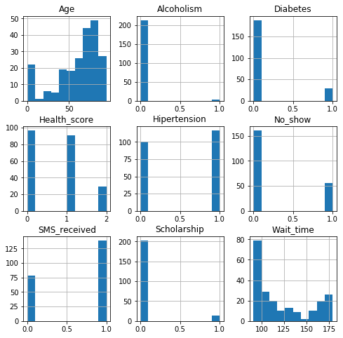

```python
df.query('Time_groups == "Very_long"').hist(figsize=(8,8));
```

- To further analyze this, will compare age distribution of this group with the worst performing group (long wait-time)

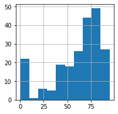

```python
df.query('Time_groups == "Very_long"')['Age'].hist(figsize=(3,3));
```

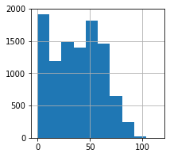

```python
df.query('Time_groups == "Long"')['Age'].hist(figsize=(3,3));
```

For the worst performing group(Long), age distribution is relatively young (more than 50% are younger than 50 years).

### Research Question 3:

**Are poor patients more inclined to miss appointments than other patients?**

- Compare absene rates between groups

```python
df[absent].Scholarship.value_counts()/df.Scholarship.value_counts()
```

```
0    0.198074
1    0.237363
Name: Scholarship, dtype: float64
```

#### Insight 3.0:

Poor families tends to have **slightly** higher absence rate than others. Will check some other factors that may/may not be contributing to this

- First, will explore whether families on scholarships have longer wait-times

```python
scholarship = df.Scholarship == 1
no_scholarship = df.Scholarship == 0
```

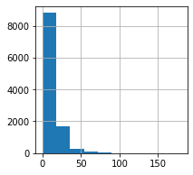

```python
df[scholarship]['Wait_time'].hist(figsize=(3,3));
```

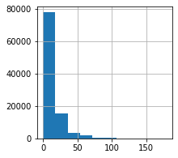

```python
df[no_scholarship]['Wait_time'].hist(figsize=(3,3));
```

#### Insight 3.1:

Wait time is pretty similar for patients who are on scholarship and patients who aren't. Hence it doesn't explain the difference in absence rate.

- **Another factor to explore is how patients groups respond to SMS messages.**  
  In esscence, I'll compare the percentage of patients that received SMS messages and yet didn't show up.
- Calculate absence distribution. i.e. percentage of patients missing appointments for two groups:
  - low income group: patients on Scholarship scheme
  - Others group: all other patients

```python
low_income_dist = df.SMS_received[scholarship][absent].sum()/df.SMS_received[scholarship].sum()
low_income_dist
```

```
0.3378031383737518
```

```python
others_dist = df.SMS_received[no_scholarship][absent].sum()/df.SMS_received[no_scholarship].sum()
others_dist
```

```
0.2689433029990306
```

- Finally, visualize results

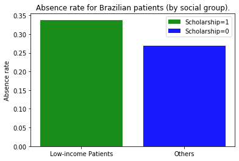

```python
plt.bar('Low-income Patients', low_income_dist, alpha=0.9, color='green', label='Scholarship=1')
plt.bar('Others', others_dist, alpha=0.9, color='blue', label='Scholarship=0')
plt.ylabel("Absence rate")
plt.title('Absence rate for Brazilian patients (by social group).')

plt.legend();
```

#### Insight 3.2:

Low income patients tend to be less responsive to SMS reminders relative to other patients. More than one-third of patients received an SMS reminder but still didn't show up.

### Research Question 4:

**How do medical conditions (Hipertension, Diabetes, and/or Alcoholism) affect patients' commitment to attend appointments?**

- Check Health score distribution

```python
df.Health_score.value_counts()
```

```
0    85311
1    17582
2     7377
3      256
Name: Health_score, dtype: int64
```

*Majority of patients have a high health score (0)*

- Next, calculate absence distribution. i.e. percentage of patients missing appointments for each group

```python
health_dist = df.Health_score[absent].value_counts()/ df.Health_score.value_counts()
health_dist
```

```
0    0.209094
1    0.177966
2    0.177037
3    0.179688
Name: Health_score, dtype: float64
```

- Finally, visualize results

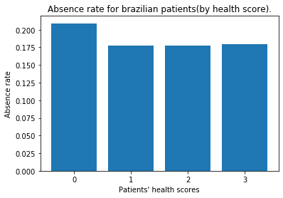

```python
health_labels = ['0','1','2','3']
plt.bar(health_labels,health_dist)
plt.xlabel("Patients' health scores")
plt.ylabel("Absence rate")
plt.title("Absence rate for brazilian patients(by health score).");
```

#### Insight 4:

Based on data available, I believe there is no strong relationship,if any, between medical conditions and being absent to doctors appointments.  
**Question may require other tools to be investigated further**

## Conclusions

The main idea behind this dataset is to explore factors that may be associated with patients not showing up to doctors' appointments. It goes without saying that correlation doesn't entail causation. However, some factors seem to be **linked** with not showing up to appointments.

### Findings:

1. Patients from different age groups seem have different levels of commitment regarding medical appointments. This is true for both males and females.
2. There is a positive correlation between length of wait-time and absence rate. More waiting time(in days) before appointments generally leads to more patients not showing up.
3. Low income families has more tendency to miss medical appointments than others. They're also generally less responsive to SMS reminders
4. No obvious relation between patients' health issues and absence rate.

#### Limitations

- Since 10 factors are available, it's very tough to make clear cut conclusions on the data. This is because there are dozens of different relationships to explore beyond this assignemnt. For this reason, other tools like machine learning & neural networks can be helpful.
- Other Socio-economic factors, i.e. income, local health system, etc., may be helpful to understand relationships more deeply.